# Homework 09

The kernel-tuning question moved here from Homework 08. A solution for Question 1 will be available after Monday, October 26, 2026. No solution will be provided for Question 2.

## Question 1: Choosing an SVM kernel

Use `saheart.csv` from the combined ZIP. As in Homework 7, predict `chd` using the same nine predictors, coding `famhist` as 1 for `Absent` and 2 for `Present`.

Compare SVMs with a linear kernel, polynomial kernels of degrees 2 (quadratic), 3, and 4, and a radial basis kernel. Choose **no more than 20 candidate settings in total** across these kernels. Vary the cost $C$ for each kernel and the radial scale $\gamma$ for the radial kernel. State any other kernel settings you hold fixed.

Divide the observations into five folds yourself and use the same folds for all candidates. Standardize predictors using only the fitting observations in each fold. Report the candidate settings and their mean cross-validation misclassification rates. Which kernel and settings do you prefer? Give a brief justification.

### Question 1 solution

I use **20 candidate models**: four values of cost for each of the linear, quadratic, cubic, and quartic kernels (16 models), and four cost–gamma combinations for the radial kernel. All predictors are standardized separately within each training fold, and the same stratified five-fold partition is reused for every candidate. The polynomial kernel uses `gamma = 1/9` and `coef0 = 1` throughout; its degree is 2, 3, or 4. The radial kernel uses the gamma values listed in the results. The SVM classification tolerance and other options are left at the `e1071::svm()` defaults.

| Kernel | Degree | C | Gamma | Mean CV error |
| --- | --- | --- | --- | --- |
| linear | NA | 0.01 | NA | 0.2943 |
| linear | NA | 0.10 | NA | 0.2685 |
| linear | NA | 1.00 | NA | 0.2685 |
| linear | NA | 10.00 | NA | 0.2707 |
| polynomial | 2 | 0.01 | 0.1111 | 0.3442 |
| polynomial | 2 | 0.10 | 0.1111 | 0.2618 |
| polynomial | 2 | 1.00 | 0.1111 | 0.2575 |
| polynomial | 2 | 10.00 | 0.1111 | 0.2856 |
| polynomial | 3 | 0.01 | 0.1111 | 0.3204 |
| polynomial | 3 | 0.10 | 0.1111 | 0.2553 |
| polynomial | 3 | 1.00 | 0.1111 | 0.2836 |
| polynomial | 3 | 10.00 | 0.1111 | 0.3291 |
| polynomial | 4 | 0.01 | 0.1111 | 0.2835 |
| polynomial | 4 | 0.10 | 0.1111 | 0.2575 |
| polynomial | 4 | 1.00 | 0.1111 | 0.2986 |
| polynomial | 4 | 10.00 | 0.1111 | 0.3486 |
| radial | NA | 0.10 | 0.0100 | 0.3463 |
| radial | NA | 1.00 | 0.0100 | 0.2791 |
| radial | NA | 1.00 | 0.1000 | 0.2618 |
| radial | NA | 10.00 | 0.1000 | 0.2944 |

**Preferred model.** The lowest mean five-fold misclassification rate belongs to the **polynomial** kernel (degree 3), with **C = 0.1** and gamma = 0.1111. Its mean CV error is **0.2553**. I prefer this setting because it gives the smallest out-of-fold misclassification rate among the 20 candidates using identical splits and training-only standardization. Small differences in CV error may be due to sampling variability, so this comparison is not evidence that the selected kernel will always outperform the others.

## Question 2: Write and use a short SVM analysis skill

In Homework 8, you reviewed another student’s skill. Review the comments and suggestions you received on your own Homework 7 skill. Use what you learned from both sides of the peer review to write a new, shorter skill for SVM model fitting.

**Write the skill by hand.** Create a `SKILL.md` with a short name and description in YAML frontmatter. Write the entire file yourself, without asking AI to draft or edit it. The instruction body after the closing `---` of the frontmatter must be **no more than 50 lines**, including blank lines. Keep the skill independent of any particular dataset, variable names, or observed results, and load it only when you explicitly invoke it.

Your skill should direct the agent to:

1. judge whether the data are suitable for an SVM analysis;
2. choose which kernels to consider and explain why;
3. identify tuning parameters and a method for tuning them;
4. choose an evaluation method that supports selecting a final model;
5. require a compact figure and table that justify the choices;
6. interpret the fit and report the key numerical results; and
7. prioritize the evidence needed to justify the final model in **no more than one printed page at 11-point font**.

**Apply the skill.** Explicitly invoke your skill to analyze `saheart.csv`, using the same response, nine predictors, and `famhist` coding as in Question 1. Provide these data details when invoking the skill, not in the skill itself. Let the skill guide the analysis, then check the resulting report and calculations.

**Submit the results.** Include the one-page, 11-point analysis report in your Homework 09 submission and append the complete contents of your `SKILL.md` afterward. The appended skill is outside the one-page limit.

## Question 2 analysis: SVM model selection

**Data and suitability.** The 462 observations contain 160 CHD cases (34.6%) and no missing values. I predict binary `chd` from sbp, tobacco, ldl, adiposity, famhist, typea, obesity, alcohol, and age, coding famhist as Absent=1 and Present=2. All nine supplied predictors enter the model; no identifier or response-derived feature enters it. SVMs suit these numerical inputs, although the small observational sample limits generalization and causal interpretation.

**Design and tuning.** With seed 9092, I reserve a stratified 25% test set (116 observations; 40 cases), leaving 346 for fitting (120 cases). I construct five stratified training folds and reuse them for every candidate. Each fold’s means and sample standard deviations scale both its fitting and validation observations; test scaling uses only the full training set. No imputation is needed. Linear models provide a simple baseline; RBF models allow nonlinear boundaries. Polynomial models add complexity without a specific rationale here; Question 1 assesses them separately.

I evaluate 20 settings: linear C in {0.01, 0.1, 1, 10}, and the same C values crossed with RBF gamma in {0.001, 0.01, 0.1, 1}. Other e1071 SVM settings remain at defaults; class weights are equal. Selection maximizes mean fold balanced accuracy (BA), the average of sensitivity and specificity, to weight both classes equally. Before evaluation, I specify preferring linear when its best BA is within one standard error of the best RBF; ties within a kernel favor smaller C, then smaller gamma. The figure shows each kernel’s best setting; bars show fold SD, not confidence intervals.

| Kernel | C | Gamma | CV BA (SD) | Test BA |
| --- | --- | --- | --- | --- |
| Linear | 10 | — | 0.682 (0.067) | 0.644 |
| RBF | 10 | 0.01 | 0.675 (0.071) | Not evaluated |

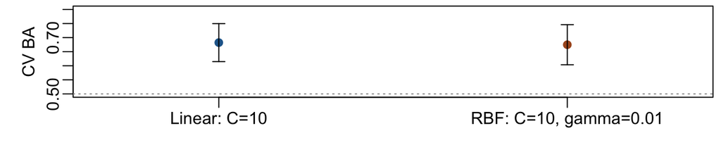

**Selection and final evaluation.** Linear C=10 has higher CV BA (0.682 versus 0.675), so I retain it and refit on all 346 training observations. On the untouched test set, TN=58, FP=18, FN=19, TP=21: sensitivity=21/40=52.5%, specificity=58/76=76.3%, BA=64.4%, accuracy=79/116=68.1%, and misclassification=37/116=31.9%. A constant non-CHD prediction has 65.5% accuracy but only 50% BA. Thus discrimination at the default decision threshold is modest, with 19 of 40 cases missed. Fold variation exceeds the kernel difference; the data do not establish a reliable nonlinear advantage. This is an internal holdout evaluation, not external validation, and estimates depend on the split. The saved predictions, folds, and unrounded CV results support arithmetic and leakage checks.

## Appendix: complete SKILL.md

```
---
name: svm-model-review
description: Evaluate binary classification data with tuned support vector machines and present concise, evidence-based model selection.
---

# SVM Model Review

1. Confirm the response is a binary class label and assess sample size, class balance, missingness, predictor types, and potential leakage. State whether SVM is suitable and any limitations.
2. Honor the response, predictors, and categorical coding supplied at invocation; do not infer or silently change them.
3. Split data using stratification where feasible. Fit imputation, categorical encoding, and numerical scaling only within training folds through a pipeline.
4. Compare a linear kernel as an interpretable baseline and an RBF kernel for nonlinear boundaries. Consider polynomial only if a substantive rationale and sample size support its added complexity.
5. Tune regularization C for all kernels; tune gamma for RBF and gamma/degree/coef0 as applicable for polynomial. Specify a reproducible grid or randomized search, seeds, and stratified cross-validation.
6. Select models using an appropriate prespecified metric (e.g., ROC AUC for discrimination, balanced accuracy when classes are imbalanced), with secondary metrics and uncertainty or fold variability.
7. Use nested cross-validation for an unbiased selection-performance estimate when feasible; otherwise reserve an untouched stratified test set and tune only on training data.
8. Include a compact figure comparing candidate performance or tuning sensitivity and a compact table with kernel, best parameters, validation results, and final evaluation metrics.
9. Choose the simplest competitive model, explain the selection using measured evidence, and report sample counts, class prevalence, selected hyperparameters, numerical scores, and key errors or confusion-matrix counts.
10. Interpret what the fit supports without causal claims; identify uncertainty and limitations. Check metric arithmetic, data leakage, reproducibility, and agreement between figure, table, and text.
11. Keep the analysis report to no more than one printed page at 11-point font; prioritize evidence needed to justify the final model. Place the complete skill text after the report, outside its page limit.
```